# Your Digest for Sunday, Oct 15, 2023 10:59 PM

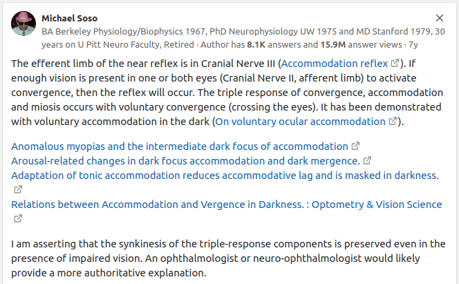

[Source](https://www.quora.com/Why-does-near-reflex-is-preserved-in-optic-nerve-lesions)

# Autonomic nervous system and organization

> [!INFO]  
> The parasympathetic outflow is from CN 3,7,9,10.  
> The nerves other than 10 provide parasympathetic plexuses within the skull.  
> PNS and SNS both have actylcholine secreted by the preganglionic neuron. Both have nicotinic receptors on the post ganglionic neurons.  
> However, in the the SNS post ganglionic neurons secretes epinephrine or norepinephrine.  
> In the PNS, the post ganglionic neurons secretes acetylcholine which binds to muscarinic receptors on the effector organ.

[figure not shown]

# Vagus nerve anatomy

#2020BSQ-JUL/Q55

Dorsal nucleus of the vagus nerve is a **mixed** visceral afferent and efferent nucleus.  
It supplies the gut upto the distal transverse colong (midgut / hindgut junction)  
Nucleus ambiguus -> supplies efferent fibers to striated muscle of the pharynx and larynx.

Passes through the jugular foramen.  
Lies in the posterior carotid sheath.  
Superior laryngeal branch supplies larynx above the vocal folds.  
Recurrent laryngeal nerve is given off the right vagus nerve.

The vagi enter the abdomen through the oesophageal opening of the diaphragm.

In unilateral paralysis of the vagal nerve, the uvula deviates to the *normal side.*

# Glossopharyngeal nerve lesions

> Complete section of the glossopharyngeal nerve results in
> 1. *sensory loss in the pharynx*, ?absent gag reflex
> 2. *loss of taste and common sensation over the **posterior one-third of the tongue***,
> 3. some pharyngeal weakness and
> 4. *loss of salivation from the **parotid gland***

# Anatomy of the spinal cord

> In adults, the cord terminates at the level of **L1-L2**. Thus the cord spans within 20 bony vertebrae. In a child, it terminates at the upper border of **L3**.

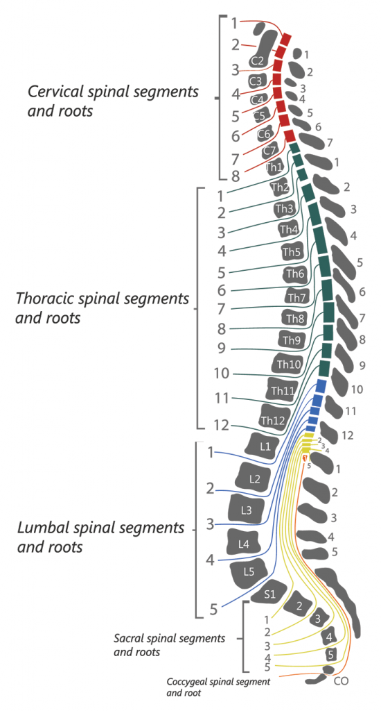

> [!INFO] Levels  
> Each intervertebral foramina contains the numerically corresponding spinal nerve. However, the spinal segment directly behind a particular vertebral body is about 1(upper thoracic) or 2 (lower thoracic) segments lowers.

# Cauda equina syndrome

> The cauda equina is made up of the *ascending* and *descending* nerve roots from **L2 to the coccygeal segments.** It is responsible for lower limb movement and sensation, bladder control/urination, external anal sphincter control and defecation, sexual function, and sensation of the genitalia and perineal region. Commonest cause is disk prolapse. [Source](https://www.acepnow.com/article/learn-to-spot-and-treat-cauda-equina-syndrome/)

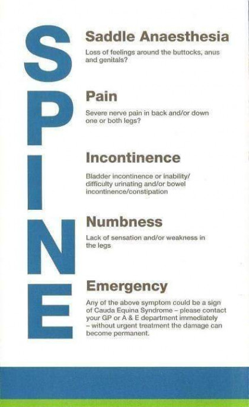

# Microcytic anaemias

Four main causes

- Iron deficiency - commonest
- Anaemia of chronic disease
- Thalassemia
- Sideroblastic

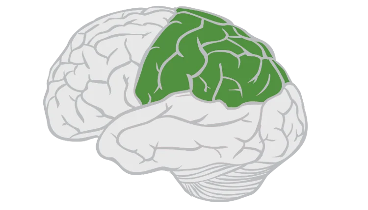

The parietal lobe integrates sensory information into a 'perception' within 3D space.  
i.e Seeing pans, pots and a cooker is perceived as a 'kitchen' and your orientation with respect to it.  
The parietal love is also required for learning and carrying out complex movements.

Parietal love dysfunction results in :

1. Agraphia - inability to write
2. acalculia - inability to do math
3. alexia - inability to read
4. Left right agnosis (inability to tell left from right)
5. Finger agnosis (inability to identify fingers separately)
6. Astereognosis - inability to identify and object by touch
7. Occulomotor apraxia - loss of voluntary control of gaze
8. simultagnosis (inability to identify things in context - i.e can see trees but can't recognise forrest)
9. Optic apraxia - reaching for something and missing while looking at it.

"Sample variance" here actually means "estimate of the population variance" based on the variance of the sample that we have. Hence, the sum of differences is divided by n-1 and not n. (where n = sample size).